# AIMS Data Platform R Client Notebook Example

Back

This example assumes you have obtained an *AIMS Data Platform API Key*. See here to see what that means. To download and run this example interactively in *R Studio* click on `Code -> Download Rmd` in the top right corner of this document.

Once you have obtained your API Key past it in the following code chunk and it will be used throughout this tutorial:

```r
# paste your key where it says api-key-for-r-notebook
MY_API_KEY <- "api-key-for-r-notebook"
```

## Install R Client

*AIMS Data Platform R Client* can be installed directly from [github](https://github.com/aims/data-platform-r) using the following code:

```r
install.packages("devtools")
devtools::install_git("https://github.com/AIMS/data-platform-r")
library(aimsdataplatform)
```

## Discover a dataset

Suppose we want to query a data series and plot it then the procedure might be:

1. Examine documentation and establish query filters
2. Perform data download using `getData`
3. Use R `plot` to create a chart

We decide to query the [AIMS Weather](https://aims.github.io/data-platform/weather) data set based on a data series, then we are guaranteed of getting information from one site for one metric.

To discover a data set we look up the filter values available for a series:

```r
getFilterValues('10.25845/5c09bf93f315d', 'series')
```

|  | series_id | series_name |
| --- | --- | --- |
| 1 | 2910 | Darwin NRS Buoy Maximum Wind Speed 10 Minutes |
| 2 | 201 | Heron Island Weather Station Maximum Wind Speed 10 Minutes |
| 3 | 128 | Ningaloo Reef Platform Air Temperature |
| 4 | 82 | Square Rocks Platform Air Pressure |
| 5 | 129 | Ningaloo Reef Platform Wind Speed (Scalar avg 10 min) |
| 6 | 2581 | Darwin NRS Buoy Wind Speed (Scalar avg 10 min) |
| 7 | 9847 | Cleveland Bay North Cardinal Marker Minimum Wind Speed 10 Minutes |
| 8 | 4184 | Cape Bowling Green Platform Humidity |
| 9 | 189 | Heron Island Weather Station Air Temperature |
| 10 | 130 | Ningaloo Reef Platform Wind Direction (Vector Average 10 Minutes) |

[output cut: 154 more lines]

The benefits to choosing a data series is that it comes from one location and parameter type, making the data easy to plot. If we did not choose a data series from the *AIMS Weather* data set we might have to specify additional parameters to ensure the data is as expected.

Finally our values and filters might look like the following:

| Variable | Value | Description |
| --- | --- | --- |
| doi | 10.25845/5c09bf93f315d | DOI for AIMS Weather found [here](https://aims.github.io/data-platform) |
| series | 64 | Found [here](https://aims.github.io/data-platform/weather/series), Davies Reef Air Temperature data series |
| from-date | ‘2018-01-01’ | We want to start charting on 1/1/2018 |
| thru-date | ‘2018-01-10’ | We are plotting 10 days of data |

## Query and Plot Dataset

After deciding on query parameters we plug the series id into a `getData` function:

```r
results <- getData('10.25845/5c09bf93f315d', apiKey=MY_API_KEY, filters=list('series'=64, 'from-date'='2018-01-01', 'thru-date'='2018-01-10'))
```

```
[1] "Cite this data as: Australian Institute of Marine Science (AIMS). 2009, Australian Institute of Marine Science Automatic Weather Stations, https://doi.org/10.25845/5c09bf93f315d, accessed 3 September 2019.  Time period: 2018-01-01 to 2018-01-10.  Series: Davies Reef Platform Air Temperature"
[1] "Result count: 1297"
```

Now the results have been stored in the `results` object we can attempt to plot.

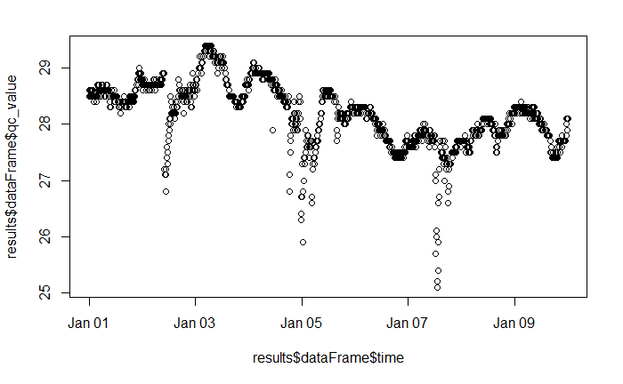

```r
plot(results$dataFrame$time, results$dataFrame$qc_value)
```

Ok we have a plot, fairly unpleasant looking, that should be a line chart:

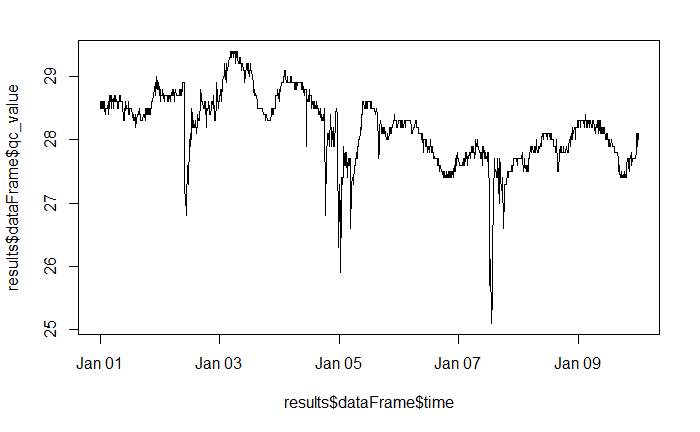

```r
plot(results$dataFrame$time, results$dataFrame$qc_value, type='l')
```

Lets add some proper labels:

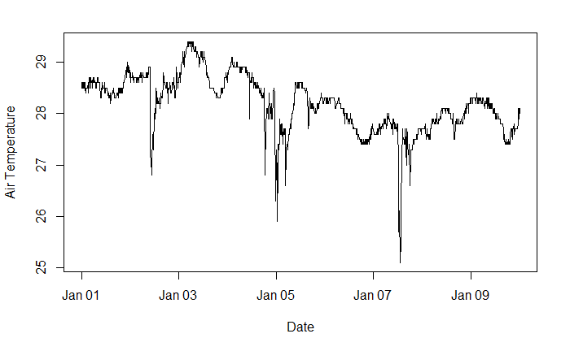

```r
plot(results$dataFrame$time, results$dataFrame$qc_value, type='l', xlab="Date", ylab="Air Temperature")
```

Finally lets make the colour green and add a main title.

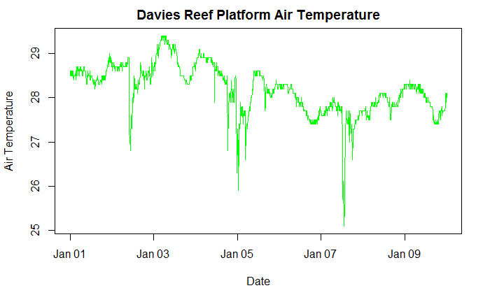

```r
plot(results$dataFrame$time, results$dataFrame$qc_value, type='l', xlab="Date", ylab="Air Temperature", main="Davies Reef Platform Air Temperature", col='green')
```

And add another series:

```r
results2 <- getData('10.25845/5c09bf93f315d', apiKey=MY_API_KEY, filters=list('series'=87929, 'from-date'='2018-01-01', 'thru-date'='2018-01-10'))
```

[output not shown]

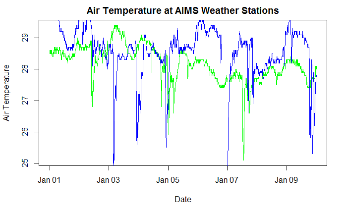

```r
plot(results$dataFrame$time, results$dataFrame$qc_value, type='l', xlab="Date", ylab="Air Temperature", main="Air Temperature at AIMS Weather Stations", col='green')
lines(results2$dataFrame$time, results2$dataFrame$qc_value, col="blue")
```

Now a legend to distinguish data sets

```r
plot(results$dataFrame$time, results$dataFrame$qc_value, type='l', xlab="Date", ylab="Air Temperature", main="Air Temperature at AIMS Weather Stations", col='green')
lines(results2$dataFrame$time, results2$dataFrame$qc_value, col="blue")
```

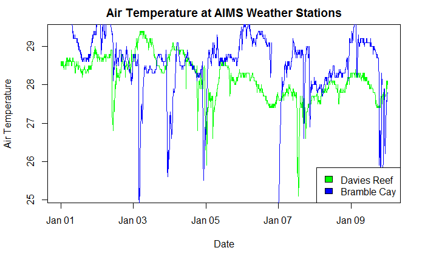

```r
legend("bottomright", c("Davies Reef", "Bramble Cay"), fill=c("green", "blue"))
```

Finally citations can be added to our document with the following code:

```r
results$citation
```

```
[1] "Australian Institute of Marine Science (AIMS). 2009, Australian Institute of Marine Science Automatic Weather Stations, https://doi.org/10.25845/5c09bf93f315d, accessed 3 September 2019.  Time period: 2018-01-01 to 2018-01-10.  Series: Davies Reef Platform Air Temperature"
```

```r
results2$citation
```

```
[1] "Australian Institute of Marine Science (AIMS). 2009, Australian Institute of Marine Science Automatic Weather Stations, https://doi.org/10.25845/5c09bf93f315d, accessed 3 September 2019.  Time period: 2018-01-01 to 2018-01-10.  Series: Bramble Cay Weather Station Air Temperature"
```

## Bibliography

1. Australian Institute of Marine Science (AIMS). 2009, Australian Institute of Marine Science Automatic Weather Stations, https://doi.org/10.25845/5c09bf93f315d, accessed 3 September 2019. Time period: 2018-01-01 to 2018-01-10. Series: Davies Reef Platform Air Temperature
2. Australian Institute of Marine Science (AIMS). 2009, Australian Institute of Marine Science Automatic Weather Stations, https://doi.org/10.25845/5c09bf93f315d, accessed 3 September 2019. Time period: 2018-01-01 to 2018-01-10. Series: Bramble Cay Weather Station Air Temperature